# Nutritional status of Women in Ethiopia

Analysis of the 2016 Ethiopian DHS Data

# 1. About BMI

**Body Mass Index (BMI)** is a widely utilized anthropometric measurement designed to assess body weight relative to height, serving as a proxy indicator for body fatness in population health studies and clinical practice. Originally introduced by Adolphe Quetelet in the 19th century called Quetelet’s index, BMI is calculated by dividing an individual’s weight in kilograms by the square of their height in meters (kg/m²). Due to its simplicity, cost-effectiveness, and ease of use, BMI has become a standard screening tool employed by healthcare professionals and researchers worldwide. Despite its limitations BMI is widely used as a measure of nutritional status. In this analysis we used BMI as a proxy for nutritional status in reproductive age women.

# 2. Setting and Data source

The area for this analysis is Ethiopia. Ethiopia is the second-most populous country in Africa next to Nigeria with a population of more than one hundred million. Administratively, Ethiopia is divided into eleven geographical regions (Tigray, Afar, Amhara, Oromia, Somali, Benishangul-Gumuz, SNNPR, Gambella, and Harari, as well as newly added Sidama and South West Ethiopia regions) and two administrative cities, Addis Ababa and Dire Dawa. Ethiopia shares the boundaries in the North with Eritrea, in the South with Kenya and Somalia, in the West with South Sudan and North Sudan, and in the East with Djibouti and Somalia.

[figure not shown]

Figure 1: Location and map of Ethiopia

Adapted from here

This analysis was from a recent standard Demographic and Health Survey (DHS) of Ethiopia. The data used for this analysis was downloaded from MEASURE DHS [website](https://dhsprogram.com/data/available-datasets.cfm). We used the Individual Recode (IR) file to navigate BMI of reproductive age women across different sociodemographc and other relevant variables.

# 3. Sample selection procedure

## 3.1. Population

The population of this analysis are reproductive age women (15 - 49 years) form the IR file. The 2016 Ethiopian Demographic and Health Survey (EDHS) has 15683 representative sample from the entire country.

## 3.2. Sample selection

The DHS has recommendations for the calculation of BMI in reproductive-age women. The recommendations can be found at the DHS . BMI is not applicable for pregnant and two months postpartum women. There are missing height (or weight) measurements and implausible results. The DHS Program provides specific guidelines for the analysis of BMI among women of reproductive age, which are detailed in the Guide to DHS Statistics available [here](https://dhsprogram.com/data/Guide-to-DHS-Statistics/index.cfm).

According to DHS recommendations, BMI should not be calculated or interpreted for women who are currently pregnant or within two months postpartum. During pregnancy and the immediate postpartum period, a woman’s weight is significantly influenced by gestational changes such as increased fluid retention, fetal mass, and physiological adaptations. Including these women in BMI analyses may result in misleading conclusions about nutritional status.

In addition to excluding pregnant and recently postpartum women, the DHS protocol advises the exclusion of cases with missing anthropometric data—specifically height or weight—as these are essential for accurate BMI computation. Furthermore, implausible values should be excluded from analysis. These include biologically improbable height or weight measurements or BMI values that fall outside acceptable ranges (12 - 60kg/m²). We excluded;

After exclusions, the final sample is **13505** reproductive age women.

## 3.3. Categories of BMI

The World Health Organization ([WHO](https://iris.who.int/handle/10665/42330)) classifies BMI into defined categories: underweight (BMI < 18.5), normal weight (18.5–24.9), overweight (25.0–29.9), and obese (≥ 30.0). These thresholds are associated with varying levels of risk for developing non-communicable diseases such as cardiovascular disease, type 2 diabetes mellitus, and certain cancers. As such, BMI plays a central role in public health surveillance, risk stratification, and policy development.

# 4. Descriptive Statistics

## 4.1. Descriptive summary

The mean height and weight of the women was 1.57m and 51.81Kg respectively. The BMI ranges from 12.08Kg/m² to 56.06Kg/m², with mean BMI of 20.87Kg/m². The prevalence of underweight is 24.89% and overweight is 8.89%.

| Nutritional status | Number | Percentage |
| --- | --- | --- |
| Underweight | 3362 | 24.89 |
| Normal weight | 8588 | 63.59 |
| Overweight | 1201 | 8.89 |
| Obese | 354 | 2.62 |

## 4.2. Anemia level and Nutritional status

Table 2 presents the distribution of anemia levels across different BMI categories among women. The majority of women in all BMI groups are not anemic, with the highest proportions seen in the obese (80.5%) and overweight (80.3%) groups, followed closely by those of normal weight (75.2%).

In contrast, underweight women have the lowest proportion of non-anemic individuals (68.6%) and the highest rates of all anemia categories, including severe anemia (1.1%), moderate anemia (7.6%), and mild anemia (22.7%). This suggests a a relation between lower BMI and increased anemia prevalence (not tested statistically).

Table 2: Anemia level and BMI among reproductive age women in Ethiopia

| Nutritional Status | Severe Anemia | Moderate Anemia | Mild Anemia | Not Anemic |
| --- | --- | --- | --- | --- |
| Underweight | 37 (1.13%) | 249 (7.59%) | 745 (22.7%) | 2251 (68.59%) |
| Normal weight | 61 (0.73%) | 453 (5.41%) | 1561 (18.63%) | 6302 (75.23%) |
| Overweight | 2 (0.17%) | 41 (3.58%) | 182 (15.91%) | 919 (80.33%) |
| Obese | - | 14 (4.2%) | 51 (15.32%) | 268 (80.48%) |

# 5. Plots of BMI and different variables

## 5.1. Place of residence and Nutritional status

The following bar graph displays the distribution of women across different BMI categories, comparing urban and rural areas. Normal weight is the most common BMI category for urban and rural women, with a higher number of rural women (5,834) than urban women (2,754). Underweight is also more prevalent among rural women (2,603) than urban women (759). In contrast, the Overweight and Obese categories show higher numbers in urban areas. For example, 870 urban women are overweight compared to 331 rural women, and 296 urban women are classified as obese versus only 58 rural women. The points are more visual observations than statistical testing and should be interpreted cautiously.

Figure 2: Distribution of women across different BMI categories based place of residence

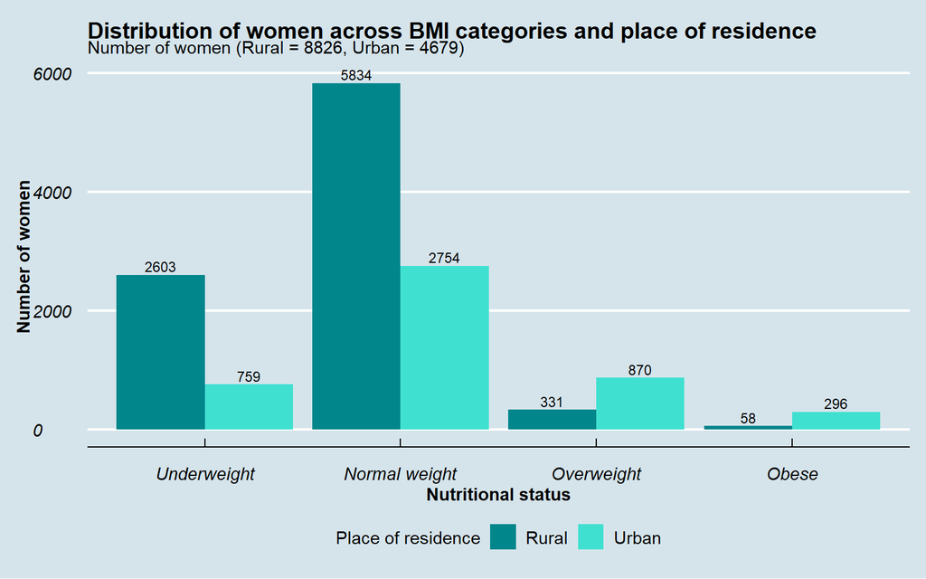

## 5.2. BMI across selected regions

Figure 3 illustrates the BMI distribution among reproductive-age women across five distinct regions of Ethiopia, drawing its data from the 2016 DHS. A clear pattern emerges, indicating significant regional disparities in the BMI profiles of women.

Afar region exhibit the lowest median BMI. Addis Ababa, the capital city, stands out distinctly with the highest BMI distribution. Its median BMI is considerably higher, approximately 23Kg/m², and its interquartile range is markedly shifted upwards, spanning from around 20.5Kg/m² to 25Kg/m². This indicates that a larger proportion of women in Addis Ababa have higher BMIs compared to women in the other four regions.

Figure 3: BMI distribution among reproductive-age women across five distinct regions of Ethiopia

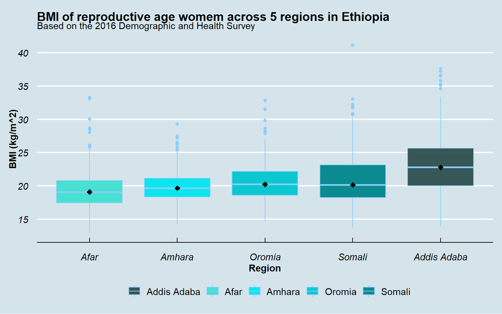

## 5.3. Relationship between BMI and age groups

Figure 4: Relationship Between age groups and BMI

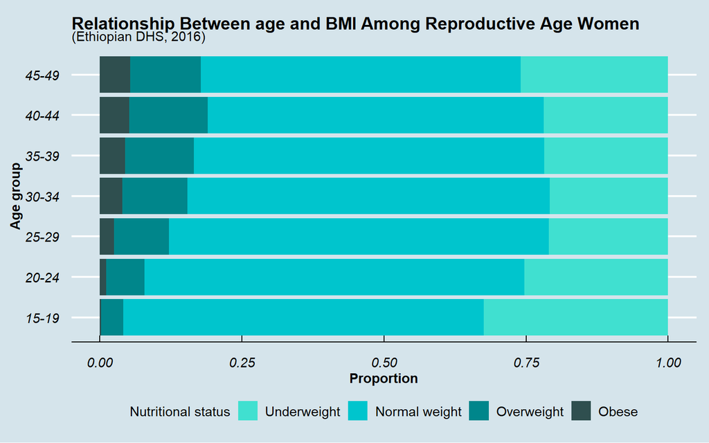

## 5.4. Wealth index and Nutritional status

Figure 5 presents a series of five pie charts illustrating nutritional status among reproductive-age women across different wealth quantiles in Ethiopia, based on the 2016 DHS. As wealth increases, there is a transition from a higher prevalence of undernutrition to a higher prevalence of overweight and obesity. The “Poorest” wealth quantile shows 38% of women being underweight and only 3% overweight, with negligible obesity. As wealth increases through “Poorer” and “Middle” quantile, the proportion of “Normal weight” women rises, and underweight decreases. However, in the “Richer” and most notably the “Richest” quantile, the trend reverses: “Normal weight” decreases (down to 60% in the richest), “Underweight” reaches its lowest point (16%), and critically, the proportions of “Overweight” (18%) and “Obese” (6%) rise notably, indicating a direct correlation between increased wealth and a higher prevalence of overweight and obesity among reproductive-age women in Ethiopia.

Figure 5: Pie charts showing nutritional status and wealth index

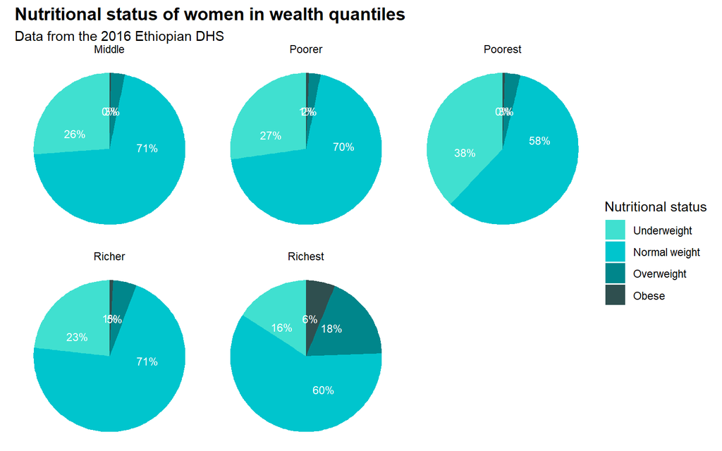

## 5.5 Number of children and BMI

Figure 6 displays the mean BMI (kg/m²) of Ethiopian women in relation to the total number of children ever born. The graph reveals a fluctuating pattern. Mean BMI initially rises with the number of children, peaking around 21.75kg/m² for women with two children. It then generally declines, reaching a low point for women with 6-7 children. Interestingly, there’s a sharp increase for women with 12 children, followed by a dip and then another significant rise for those with 14 children, suggesting a complex relationship between parity and BMI.

Figure 6: Mean BMI in relation to total number of children in Ethiopian women

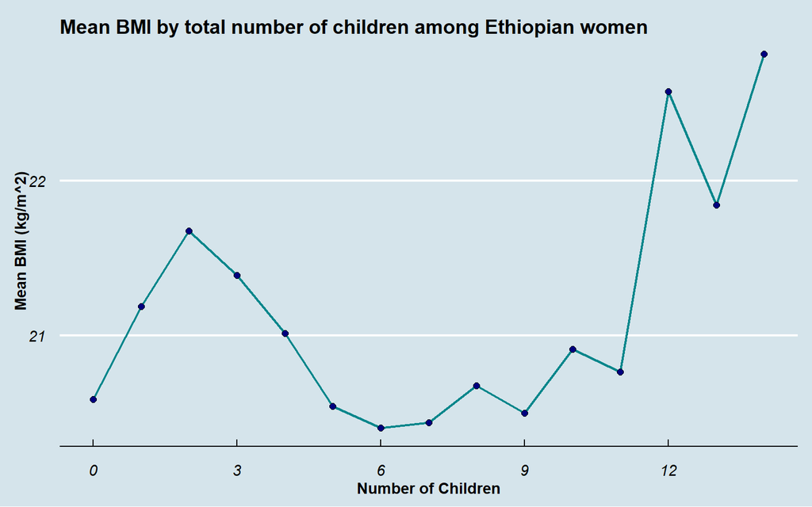